# Case Study 1: Astrophysical Time Series - Solar Cycle Analysis

## 1. Physical Context

Sunspots are temporary phenomena on the Sun's photosphere that appear as spots darker than the surrounding areas. They are regions of reduced surface temperature caused by concentrations of magnetic field flux that inhibit convection.

Historical observations of sunspots have been recorded for centuries, revealing a distinct periodicity in solar magnetic activity. This variability significantly impacts space weather, satellite communications, and the Earth's upper atmosphere.

**Your Objective:** You are provided with a historical dataset of the Monthly Mean Total Sunspot Number. Your task is to utilize the Discrete Fourier Transform (DFT) to mathematically isolate and quantify the dominant period of the solar magnetic cycle (often referred to as the Schwabe cycle).

## 2. Mathematical Expectations

The dataset provides the sunspot count $y_n$ at discrete, uniformly spaced time intervals. The sampling interval is one month, meaning $\Delta t = 1/12$ years.

You will compute the Fast Fourier Transform (FFT) to obtain the frequency-domain components $Y_k$. To find the dominant physical cycle, you must:

1. Compute the normalized power spectrum: $P_k = \frac{2}{N} |Y_k|$
2. Formulate the correct frequency array $f_k$ corresponding to the frequency bins.
3. Identify the frequency $f_{max}$ that yields the maximum spectral power.
4. Convert this frequency into a physical time period $T$ (in years) using the relation: $$T = \frac{1}{f}$$

```python
# Import required scientific libraries
import numpy as np
import matplotlib.pyplot as plt
import pandas as pd

# Set plot style for academic formatting
plt.style.use('seaborn-v0_8-darkgrid')
plt.rcParams['figure.figsize'] = (12, 6)
```

## 3. Data Loading and Time-Domain Visualization

**Task 1:** Load the dataset `sunspot_data.csv` from the `data/` directory. The dataset contains two columns: `Fractional_Year` (e.g., 1850.042) and `Sunspot_Count`. Plot the raw data in the time domain to visually inspect the periodicity and noise.

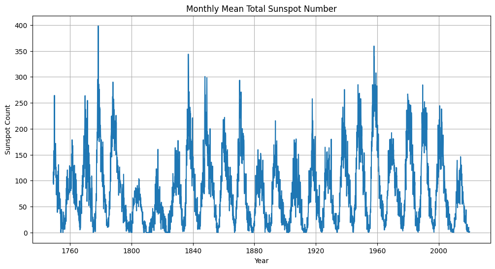

```python
# --- TASK 1: Load and plot the raw time-domain data ---

import numpy as np

import pandas as pd
import matplotlib.pyplot as plt

# Load data
df = pd.read_csv("sunspots.csv")

# Ambil kolom
t = pd.to_datetime(df["Date"])
y = df["Monthly Mean Total Sunspot Number"]

# Plot data
plt.figure(figsize=(12,6))
plt.plot(t, y)
plt.xlabel("Year")
plt.ylabel("Sunspot Count")
plt.title("Monthly Mean Total Sunspot Number")
plt.grid(True)
plt.show()
```

## 4. DC Component Removal

Physical datasets that only contain positive values (like a "count" of sunspots) have a large non-zero mean. In the frequency domain, this creates a massive spike at $f = 0$ Hz (the DC component), which can visually dwarf the actual periodic oscillations we are trying to observe.

**Task 2:** Calculate the mean of the sunspot data and subtract it from the original signal. We will perform the FFT on this mean-centered signal.

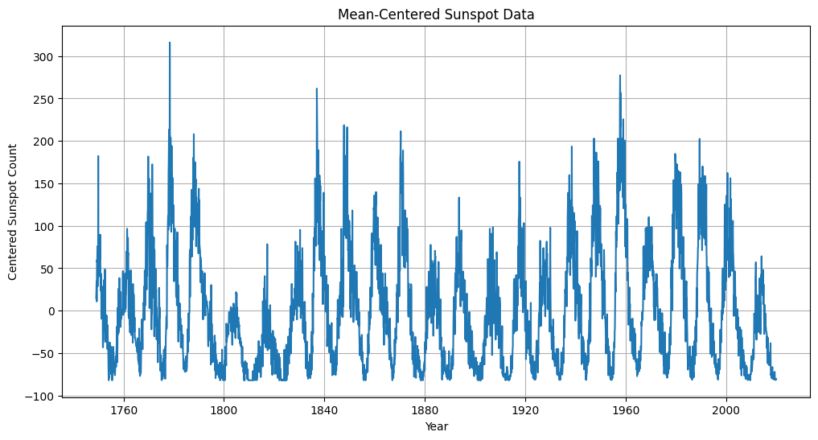

```python
# --- TASK 2: Remove the DC component ---

import numpy as np

mean_value = np.mean(y)

y_centered = y - mean_value

plt.figure(figsize=(12,6))
plt.plot(t, y_centered)
plt.xlabel("Year")
plt.ylabel("Centered Sunspot Count")
plt.title("Mean-Centered Sunspot Data")
plt.grid(True)
plt.show()
```

## 5. Frequency Domain Transformation

**Task 3:** Implement the FFT algorithm on your centered data. You must also construct the corresponding frequency axis. Pay strict attention to your units. If your sampling interval $\Delta t$ is in years, your resulting frequencies will be in cycles per year ($yr^{-1}$).

```python
# --- TASK 3: Compute the FFT and Power Spectrum ---

N = len(y_centered)

dt = 1/12  # 1 bulan = 1/12 tahun

Y = np.fft.fft(y_centered)

freq = np.fft.fftfreq(N, d=dt)

power = (2/N) * np.abs(Y)

mask = freq > 0

freq_pos = freq[mask]
power_pos = power[mask]

print("FFT selesai dihitung")
```

```
FFT selesai dihitung
```

## 6. Power Spectrum Analysis

**Task 4:** Plot the power spectrum (Magnitude vs. Frequency). Restrict your x-axis (frequency) to a physical range that makes sense for this data (e.g., $0$ to $0.5$ cycles/year) to zoom in on the relevant peaks.

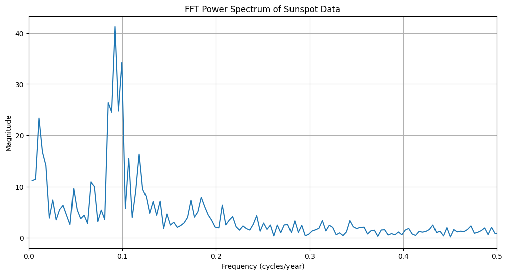

```python
# --- TASK 4: Visualize the Frequency Domain ---

plt.figure(figsize=(12,6))
plt.plot(freq_pos, power_pos)

plt.xlabel("Frequency (cycles/year)")
plt.ylabel("Magnitude")
plt.title("FFT Power Spectrum of Sunspot Data")

plt.xlim(0, 0.5)

plt.grid(True)
plt.show()
```

## 7. Conclusions and Physical Interpretation

**Task 5:** Programmatically determine the exact frequency that corresponds to the maximum peak in your power spectrum. Convert this frequency into a time period (years).

Provide a brief written analysis of your findings below. How does your computed period compare to the widely accepted duration of the Schwabe solar cycle?

```python
# --- TASK 5: Programmatic peak detection ---

peak_index = np.argmax(power_pos)

dominant_frequency = freq_pos[peak_index]

period = 1 / dominant_frequency

print(f"Dominant Frequency = {dominant_frequency:.4f} cycles/year")
print(f"Solar Cycle Period = {period:.2f} years")
```

```
Dominant Frequency = 0.0923 cycles/year
Solar Cycle Period = 10.84 years
```

### Final Analysis

**Computed Solar Cycle Period:** 10.84 years.

**Physical Interpretation:**

The FFT analysis successfully identified the dominant periodic component in the historical sunspot dataset. The dominant frequency was found to be 0.0923 cycles per year, corresponding to a solar cycle period of approximately 10.84 years. This result is very close to the widely accepted Schwabe solar cycle of about 11 years, indicating that the FFT method effectively isolated the main physical cycle despite the presence of noise in the observational data. Several smaller peaks may also be observed in the spectrum, which could be associated with harmonics, secondary solar activity variations, or mathematical artifacts caused by finite sampling and measurement uncertainties.